# Metody wyboru zmiennych w algorytmie sympleks

Dawid Dąbkowski, Anna Wójcik, Piotr Piękos

6 czerwca 2017

## Funkcje pivot

W analizie zastosowaliśmy 10 różnych funkcji wyboru zmiennych wchodzących i wychodzących:

- `largest_coefficient` - wybór zmiennej wchodzącej o największym współczynniku funkcji celu, zmienna wychodząca pierwsza z listy
- `smallest_coefficient` - wybór zmiennej wchodzącej o najmniejszym współczynniku funkcji celu, zmienna wychodząca pierwsza z listy
- `largest_increase` - wybór krawędzi o największym wzroście funkcji celu
- `smallest_increase` - wybór krawędzi o najmniejszym wzroście funkcji celu
- `steepest_edge` - wybór krawędzi o kierunku najbliższym gradientowi funkcji celu
- `flattest_edge` - wybór krawędzi o kierunku najdalszym gradientowi funkcji celu
- `lexicographical_max` - wybór zmiennej wchodzącej i wychodzącej pierwszej słownikowo
- `lexicographical_min` - wybór zmiennej wchodzącej i wychodzącej ostatniej słownikowo
- `random_edge` - wybór losowej krawędzi
- `random_variable` - wybór losowej zmiennej wchodzącej i losowej zmiennej wychodzącej

## Testy

Metody pivot zastosowaliśmy do 10 różnych problemów liniowych. Problemy te uszeregowane są rosnąco ze względu na ilość zmiennych i są to: `Furniture` (2), `WhiskasProblem2` (6), `FactoryProblem` (7), `FruitProblem` (9), `BeerDistributionProblem` (10), `CargoesProblem` (12), `BankProblem` (13), `AmericanSteelProblem` (14), `ComputerPlantProblem` (20), `ShiftProblem` (21).

W tabeli poniżej zapisana jest ilość kroków potrzebnych do znalezienia optymalnego wierzchołka dla każdej pary metoda-problem. W przypadku metod losowych (`random_edge` i `random_variable`) jako poglądowej statystyki użyliśmy średniej z 100 prób.

```
##                      V1    V2    V3    V4    V5    V6    V7    V8    V9   V10
## size                  2  6.00  7.00  9.00 10.00 12.00 13.00 14.00 20.00 21.00
## largest_coefficient   2  9.00  7.00  4.00  2.00  7.00  6.00  3.00  7.00  7.00
## smallest_coefficient  2  5.00  5.00 11.00  4.00 25.00 13.00  5.00  8.00 25.00
## largest_increase      2  3.00  5.00  4.00  2.00  7.00  5.00  4.00  7.00  7.00
## smallest_increase     2 12.00 13.00 18.00  4.00 26.00 10.00  4.00  6.00 26.00
## steepest_edge         2  7.00  6.00  4.00  2.00  7.00  6.00  4.00  7.00  7.00
## flattest_edge         2  5.00  7.00 13.00  4.00 26.00 10.00  4.00  7.00 26.00
## lexicographical_max   2  2.00  6.00 12.00  3.00 14.00  9.00  3.00  8.00 14.00
## lexicographical_min   2 11.00  8.00 10.00  2.00 12.00  7.00  5.00  7.00 12.00
## random_edge           2  5.17  6.77  8.83  2.85 11.09  8.09  3.81  6.45  6.88
## random_variable       2  4.82  6.56  8.82  2.82 11.44  8.17  3.82  6.65  6.99
```

## Analiza wyników

Zobaczmy na wykresie, jak wyglądają zależności między kolejnymi parami metod. Dodatkowo każdą parę porównamy z metodą losową `random_variable`, a dla metod losowych sporządzimy wykresy pudełkowe, by zobaczyć ich przybliżony rozkład.

### Metoda `largest_coefficient` vs `smallest_coefficient`

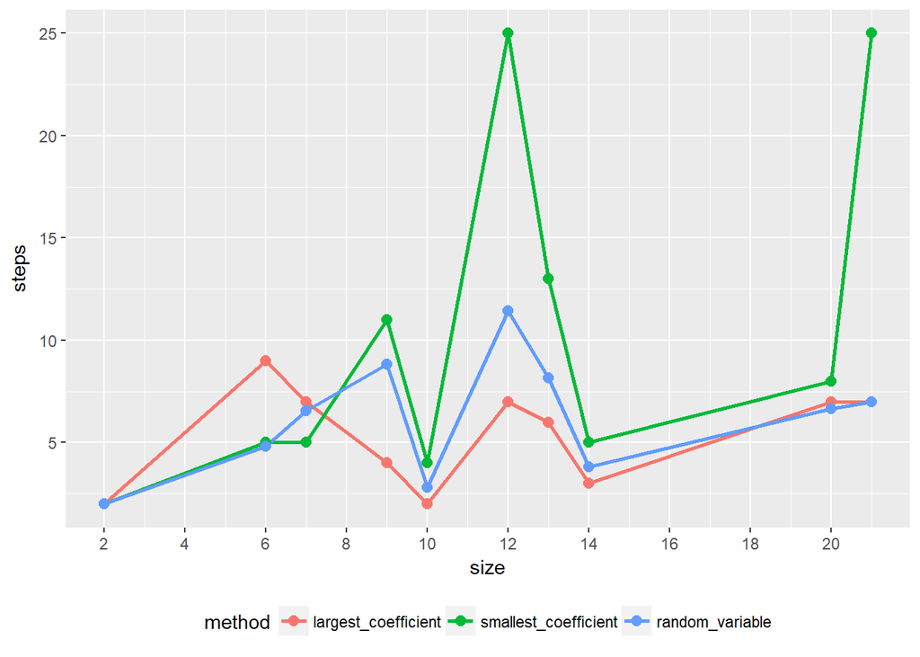

Jak widać, wykluczając bardzo małe problemy, metoda `largest_coefficient` radzi sobie lepiej niż metoda losowa. Co więcej, metoda `smallest_coefficient` radzi sobie gorzej. Wybór największych współczynników może być dobrą strategią przeszukiwania sympleksu.

### Metoda `largest_increase` vs `smallest_increase`

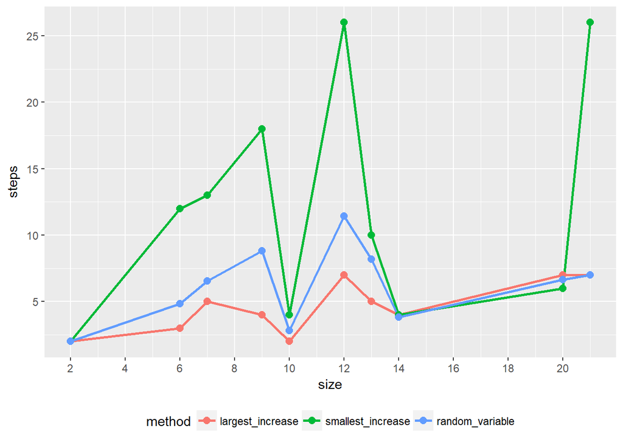

Tutaj widzimy podobnie silną zależność. Metoda `largest_increase` ogólnie radzi sobie lepiej niż metoda losowa, a metoda `smallest_increase` radzi sobie gorzej. Wybór kierunku o największym wzroście funkcji celu również może być dobrą strategią poszukiwań.

### Metoda `steepest_edge` vs `flattest_edge`

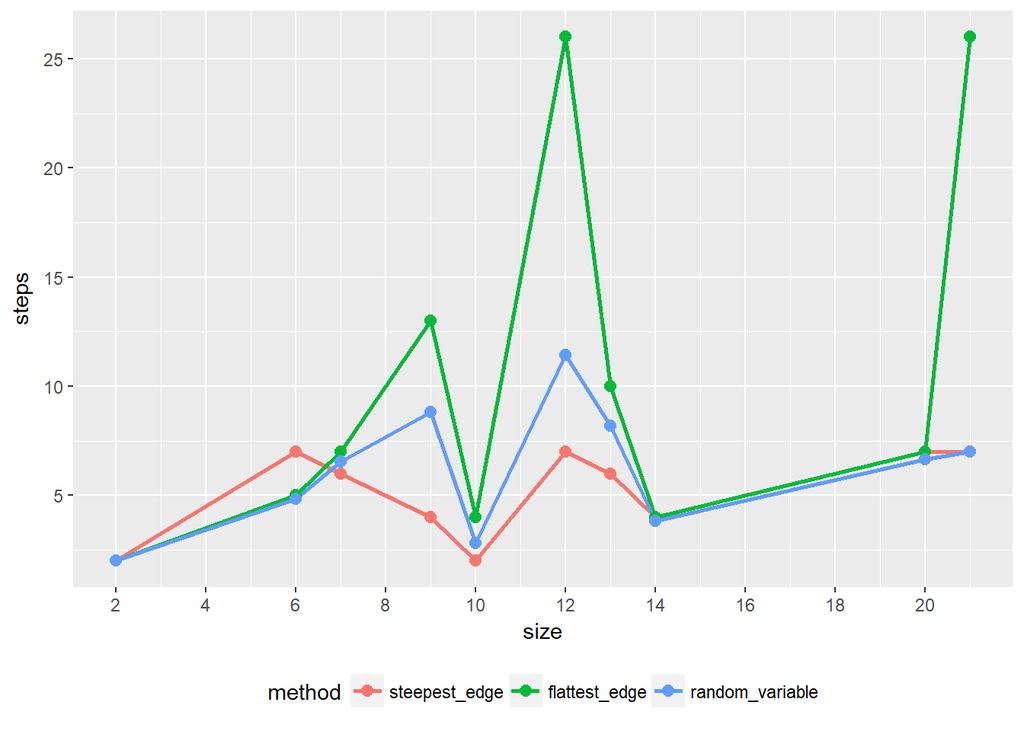

Wykres ten jest bardzo podobny do poprzedniego. Okazuje się, że chodzenie w kierunku gradientu metodą `steepest edge` daje podobny zysk jak szukanie największego wzrostu funkcji celu. Podobnie też chodzenie w kierunku przeciwnym do gradientu `flattest edge` daje podobne pogorszenie jak szukanie najmniejszego wzrostu funkcji celu. Podążanie w kierunku gradientu funkcji celu może być więc dobrą strategią.

### Metoda `lexicographical_max` vs `lexicographical_min`

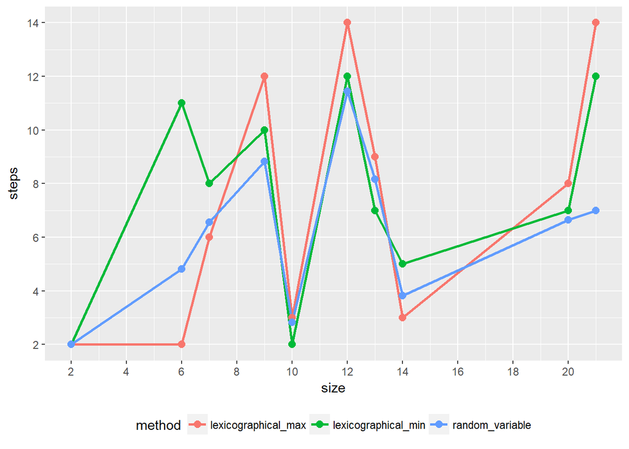

W tym przypadku zdaje się, że nie ma wyraźnej różnicy między trzema metodami. Wybór pierwszej zmiennej przez `lexicographical_max` jak i ostatniej przez `lexicographical_min` daje podobny rezultat co metoda losowa.

### Metoda `random_edge` vs `random_variable`

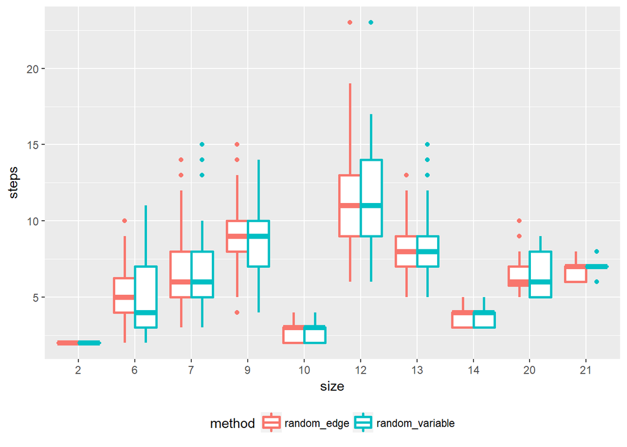

Porównując wykresy pudełkowe dla metod `random_edge` i `random_variable` raczej nie zauważamy istotnych różnic między tymi metodami.

## Podsumowanie

Dokonaliśmy porównania 10 różnych metod przeszukiwania wierzchołków w metodzie sympleks. Metody zastosowaliśmy dla 10 różnych problemów testowych. Problemy te uporządkowaliśmy ze względu na ilość zmiennych, które w nich występują (od 2 do 21). Dla dwóch ostatnich metod przeanalizowaliśmy dodatkowo rozkład wyników, gdyż metody te nie są deterministyczne.

Okazało się, że metody `largest_coefficient`, `largest_increase` oraz `steepest_edge` dają wyraźnie lepsze rezultaty, niż metody losowe. Z drugiej strony analogiczne metody `smallest_coefficient`, `smallest_increase` oraz `flattest_edge` dają rezultaty znacznie gorsze. Co więcej wynik dla `largest_increase` i `steepest_edge` jest prawie taki sam (i podobnie dla `smallest_increase` i `flattest_edge`).

Pozostałe metody czyli `lexicographical_max`, `lexicographical_min`, `random_edge` oraz `random_variable` dają podobne, średnio dobre wyniki.

Zatem najlepsze ze strategii, które poddaliśmy analizie to branie zmiennej o największym współczynniku funkcji celu, podążanie w kierunku największego jej wzrostu lub wzdłuż jej gradientu.